# GARCH, Monte Carlo y árboles binomiales: NVDA, AMD y XOM

Pronóstico de volatilidad, valuación de opciones americanas y decisión de compra

Eduardo Ayala Saldaña, Mariann Antonelli Morales Tobias y Ulises Salinas López

2026-11-01

# 1 Objetivo

Usar un modelo **GARCH(1,1)** para pronosticar la volatilidad de **NVDA, AMD y XOM** hasta el vencimiento de sus opciones (**18 de diciembre de 2026**), meter esa volatilidad en el **árbol binomial** de opciones americanas y decidir qué comprar.

El documento responde cuatro preguntas:

1. ¿Qué volatilidad espera GARCH en los próximos meses, frente a lo que cobra el mercado (volatilidad implícita)?
2. ¿Qué rango de precios deja el **Monte Carlo con GARCH** al vencimiento y a 2 semanas?
3. ¿La opción está **barata o cara** (señal = σ GARCH ÷ σ implícita) y qué tan sólida es esa señal?
4. ¿Qué se compra en Investopedia, cuánto cuesta y cuánto se espera ganar o perder?

Las cotizaciones de opciones son las capturadas en **TradingView (cierre del 30-oct-2026, capturadas el 1-nov)**. Todas las posiciones son **compras**: la pérdida máxima es la prima pagada. El método sigue la presentación del profesor (Hull, caps. 13 y 22-23) y el notebook de referencia de GARCH.

# 2 Parámetros

Aquí se cambia todo: si se actualizan las cotizaciones, basta con editar `F0` y la lista `mercado`.

```r
rm(list = ls())
leer <- function(...) {
  x <- c(...)
  cat("\n\n> **En palabras simples**\n>\n", paste0("> - ", x, "\n", collapse = ""), "\n", sep = "")
}
pc <- function(x, d = 1) sprintf(paste0("%.", d, "f %%"), 100 * x)

tickers  <- c("NVDA", "AMD", "XOM")
colores  <- c(NVDA = "seagreen", AMD = "firebrick", XOM = "darkorange")

F0       <- as.Date("2026-10-30")       # fecha de las cotizaciones (los datos históricos se cortan aquí)
FV       <- as.Date("2026-12-18")       # vencimiento
feriados <- as.Date("2026-11-26")       # Thanksgiving
r        <- 0.0394                      # tasa libre de riesgo continua (misma de la tarea de árboles)
mult     <- 100                         # acciones por contrato
N_SIM    <- 100000                        # trayectorias de Monte Carlo
lambda   <- 0.94                        # EWMA (RiskMetrics)
mu       <- 0.08                        # rendimiento esperado anual SUPUESTO para pronosticar el precio
umbral   <- 0.10                        # diferencia GARCH vs implícita que activa la señal
horiz    <- 10                          # días hábiles de la "rentabilidad a 2 semanas"
presupuesto <- 3000                     # USD por posición (igual que la tarea de árboles)
capital  <- 100000                      # capital del portafolio en Investopedia
years    <- 5                           # años de historia
set.seed(123)

# Cotizaciones (TradingView, cierre del 30-oct-2026): spot, strike, dividendo, IV, (bid, ask) y la posición de la tarea de árboles
mercado <- list(
  NVDA = list(S = 204.64, K = 200, q = 0.0047, iv = 0.4145, call = c(15.55, 15.75), put = c(9.85, 10.00), compra = "call", n = 2),
  AMD  = list(S = 504.80, K = 500, q = 0.0,    iv = 0.5864, call = c(46.85, 48.50), put = c(39.70, 40.75), compra = "put",  n = 1),
  XOM  = list(S = 187.25, K = 185, q = 0.0225, iv = 0.2991, call = c(8.75, 9.20), put = c(6.80, 7.30),  compra = "call", n = 3)
)

dias_cal <- as.numeric(FV - F0)
T_anios  <- dias_cal / 365
dd       <- seq(F0 + 1, FV, by = "day")
H        <- sum(!(format(dd, "%u") %in% c("6", "7")) & !(dd %in% feriados))   # días hábiles hasta el vencimiento
cat(sprintf("Cotización: %s | Vencimiento: %s | %d días naturales (T = %.4f años) | %d días hábiles",
            F0, FV, dias_cal, T_anios, H))
```

```
## Cotización: 2026-10-30 | Vencimiento: 2026-12-18 | 49 días naturales (T = 0.1342 años) | 34 días hábiles
```

# 3 Datos: precios y rendimientos

Los precios se descargan con `getSymbols` (Yahoo Finance, precio de cierre ajustado). Si no hay internet, se usa un archivo local: `precios_usados.csv` (una columna por acción) o `datos/NVDA.csv`, `datos/AMD.csv`, `datos/XOM.csv`. Se usa el rendimiento logarítmico $u_i = 100\ln(S_i/S_{i-1})$ (en %).

```r
library(quantmod)

bajar <- function(t) {
  tryCatch({
    x <- getSymbols(t, src = "yahoo", from = F0 - round(years * 365.25), to = F0 + 1, auto.assign = FALSE)
    s <- Ad(x); s <- zoo::zoo(as.numeric(s), as.Date(zoo::index(s)))
    if (length(s) > 300) s else NULL
  }, error = function(e) NULL)
}
leer_local <- function() {
  if (file.exists("precios_usados.csv")) {
    d <- read.csv("precios_usados.csv", check.names = FALSE)
    return(do.call(cbind, lapply(tickers, function(t) zoo::zoo(d[[t]], as.Date(d[[1]])))) )
  }
  if (all(file.exists(file.path("datos", paste0(tickers, ".csv"))))) {
    l <- lapply(tickers, function(t) { d <- read.csv(file.path("datos", paste0(t, ".csv")))
                                       zoo::zoo(as.numeric(d[[2]]), as.Date(d[[1]])) })
    return(do.call(cbind, l))
  }
  NULL
}

bajados <- lapply(tickers, bajar)
if (!any(sapply(bajados, is.null))) {
  px <- do.call(cbind, bajados); fuente <- "Yahoo Finance (getSymbols)"
} else {
  px <- leer_local(); fuente <- "Archivo local (precios_usados.csv / datos/)"
  if (is.null(px)) stop("No se pudieron obtener precios: ejecuta con internet o coloca precios_usados.csv en la carpeta.")
}
colnames(px) <- tickers
px <- na.omit(px[zoo::index(px) <= F0 & zoo::index(px) >= F0 - round(years * 365.25), ])
write.csv(data.frame(Date = zoo::index(px), zoo::coredata(px)), "precios_usados.csv", row.names = FALSE)

u <- lapply(tickers, function(t) 100 * diff(log(as.numeric(px[, t]))))
names(u) <- tickers
cat(sprintf("Fuente: %s | %d observaciones | del %s al %s\n", fuente, nrow(px), min(zoo::index(px)), max(zoo::index(px))))
```

```
## Fuente: Archivo local (precios_usados.csv / datos/) | 1255 observaciones | del 2021-11-01 al 2026-10-30
```

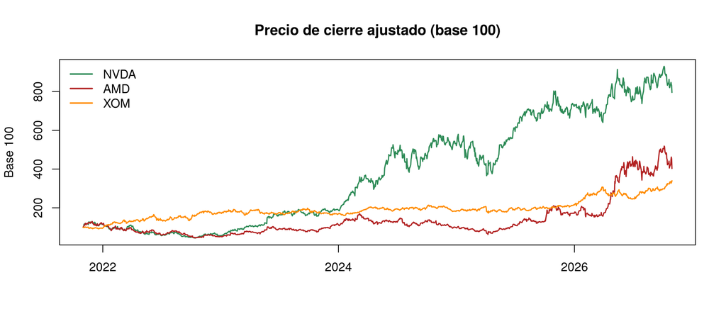

```r
base100 <- sweep(zoo::coredata(px), 2, zoo::coredata(px)[1, ], "/") * 100
matplot(zoo::index(px), base100, type = "l", lty = 1, lwd = 1.6, col = colores[tickers], xlab = "", ylab = "Base 100",
        main = "Precio de cierre ajustado (base 100)")
legend("topleft", tickers, col = colores[tickers], lty = 1, lwd = 2, bty = "n")
```

# 4 Volatilidad histórica y EWMA

```r
vol_30  <- sapply(u, function(x) sd(tail(x, 30))  * sqrt(252) / 100)
vol_1a  <- sapply(u, function(x) sd(tail(x, 252)) * sqrt(252) / 100)

var_ewma_sig <- function(x) {                      # EWMA = GARCH especial con omega = 0, alpha = 1 - lambda, beta = lambda
  v <- numeric(length(x)); v0 <- mean((x[1:30] - mean(x[1:30]))^2); v[1] <- v0
  for (i in 2:length(x)) v[i] <- (1 - lambda) * x[i - 1]^2 + lambda * v[i - 1]
  v
}
ewma_hoy <- sapply(u, function(x) { v <- var_ewma_sig(x); sqrt(252 * ((1 - lambda) * tail(x, 1)^2 + lambda * tail(v, 1))) / 100 })

hist_df <- data.frame(Accion = tickers, `Últimos 30 días` = vol_30, `Último año` = vol_1a, `EWMA hoy` = ewma_hoy, check.names = FALSE)
knitr::kable(hist_df, digits = 3, caption = "Volatilidad anual (decimal)")
```

Volatilidad anual (decimal)

|  | Accion | Últimos 30 días | Último año | EWMA hoy |
| --- | --- | --- | --- | --- |
| NVDA | NVDA | 0.296 | 0.373 | 0.342 |
| AMD | AMD | 0.661 | 0.687 | 0.724 |
| XOM | XOM | 0.219 | 0.263 | 0.240 |

```r
leer(sprintf("**%s**: en el último año la acción se movió con una volatilidad de %s; en los últimos 30 días, %s; EWMA (λ = 0.94, da más peso a lo reciente) dice %s hoy.",
             tickers, pc(vol_1a), pc(vol_30), pc(ewma_hoy)),
     "La volatilidad histórica es una **foto del pasado**. GARCH la mejora porque deja que la volatilidad cambie y regrese a un nivel normal.")
```

> **En palabras simples**
> - **NVDA**: en el último año la acción se movió con una volatilidad de 37.3 %; en los últimos 30 días, 29.6 %; EWMA (λ = 0.94, da más peso a lo reciente) dice 34.2 % hoy.
> - **AMD**: en el último año la acción se movió con una volatilidad de 68.7 %; en los últimos 30 días, 66.1 %; EWMA (λ = 0.94, da más peso a lo reciente) dice 72.4 % hoy.
> - **XOM**: en el último año la acción se movió con una volatilidad de 26.3 %; en los últimos 30 días, 21.9 %; EWMA (λ = 0.94, da más peso a lo reciente) dice 24.0 % hoy.
> - La volatilidad histórica es una **foto del pasado**. GARCH la mejora porque deja que la volatilidad cambie y regrese a un nivel normal.

# 5 GARCH(1,1) por máxima verosimilitud

$$\sigma^2_n = \omega + \alpha\,u^2_{n-1}
+ \beta\,\sigma^2_{n-1},\qquad
V_L=\frac{\omega}{1-\alpha-\beta}$$

- $\alpha$: cuánto pesa el **shock de ayer**; $\beta$: cuánto pesa la **memoria** de la volatilidad previa; $\alpha+\beta$: **persistencia**.
- $V_L$: varianza «normal» (de largo plazo) a la que regresa el modelo.
- Los parámetros se eligen para que los rendimientos observados sean lo más probables posible (verosimilitud gaussiana, Hull 23.5), con tres puntos de partida por robustez.

```r
var_garch <- function(p, x) {
  v <- numeric(length(x)); v[1] <- mean((x - mean(x))^2)
  for (i in 2:length(x)) v[i] <- p[1] + p[2] * x[i - 1]^2 + p[3] * v[i - 1]
  v
}
nll <- function(p, x) {
  if (p[2] + p[3] >= 0.9999) return(1e10)
  v <- var_garch(p, x); 0.5 * sum(log(2 * pi) + log(v) + x^2 / v)
}
ajustar_garch <- function(x) {
  v <- mean((x - mean(x))^2); mejor <- NULL
  for (ab in list(c(0.08, 0.90), c(0.05, 0.93), c(0.12, 0.80))) {
    o <- optim(c(v * (1 - sum(ab)), ab), nll, x = x, method = "L-BFGS-B",
               lower = c(1e-6, 1e-4, 0.30), upper = c(Inf, 0.5, 0.9998), control = list(maxit = 2000, factr = 1e3))
    if (is.null(mejor) || o$value < mejor$value) mejor <- o
  }
  mejor
}

fit <- lapply(u, ajustar_garch)
M <- lapply(tickers, function(t) {
  p <- fit[[t]]$par; x <- u[[t]]; v <- var_garch(p, x)
  list(p = p, u = x, v = v, VL = p[1] / (1 - p[2] - p[3]), v_next = p[1] + p[2] * tail(x, 1)^2 + p[3] * tail(v, 1), ll = -fit[[t]]$value)
}); names(M) <- tickers
vol_anual <- function(v) sqrt(252 * v) / 100

par_df <- do.call(rbind, lapply(tickers, function(t) with(M[[t]], data.frame(
  Accion = t, omega = p[1], alpha = p[2], beta = p[3], Persistencia = p[2] + p[3],
  `Vol. largo plazo` = vol_anual(VL), `Vol. hoy (GARCH)` = vol_anual(v_next),
  `Vida media del shock (días)` = log(0.5) / log(p[2] + p[3]), check.names = FALSE))))
knitr::kable(par_df, digits = 4, caption = "Parámetros GARCH(1,1) estimados")
```

Parámetros GARCH(1,1) estimados

| Accion | omega | alpha | beta | Persistencia | Vol. largo plazo | Vol. hoy (GARCH) | Vida media del shock (días) |
| --- | --- | --- | --- | --- | --- | --- | --- |
| NVDA | 0.2843 | 0.0474 | 0.9261 | 0.9736 | 0.5207 | 0.4167 | 25.8819 |
| AMD | 1.6880 | 0.0524 | 0.8191 | 0.8715 | 0.5754 | 0.7058 | 5.0405 |
| XOM | 0.0240 | 0.0351 | 0.9564 | 0.9915 | 0.2664 | 0.2459 | 80.9492 |

```r
leer(sprintf("**%s**: α = %.3f, β = %.3f, persistencia %.3f. La volatilidad de hoy es %s y GARCH espera que regrese hacia %s. Un shock tarda unos %.0f días en perder la mitad de su efecto.",
             tickers, par_df$alpha, par_df$beta, par_df$Persistencia, pc(par_df$`Vol. hoy (GARCH)`), pc(par_df$`Vol. largo plazo`), par_df$`Vida media del shock (días)`),
     "Persistencia cercana a 1 = la volatilidad cambia despacio y los sustos duran. Un α alto = reacciona fuerte al último día.")
```

> **En palabras simples**
> - **NVDA**: α = 0.047, β = 0.926, persistencia 0.974. La volatilidad de hoy es 41.7 % y GARCH espera que regrese hacia 52.1 %. Un shock tarda unos 26 días en perder la mitad de su efecto.
> - **AMD**: α = 0.052, β = 0.819, persistencia 0.872. La volatilidad de hoy es 70.6 % y GARCH espera que regrese hacia 57.5 %. Un shock tarda unos 5 días en perder la mitad de su efecto.
> - **XOM**: α = 0.035, β = 0.956, persistencia 0.991. La volatilidad de hoy es 24.6 % y GARCH espera que regrese hacia 26.6 %. Un shock tarda unos 81 días en perder la mitad de su efecto.
> - Persistencia cercana a 1 = la volatilidad cambia despacio y los sustos duran. Un α alto = reacciona fuerte al último día.

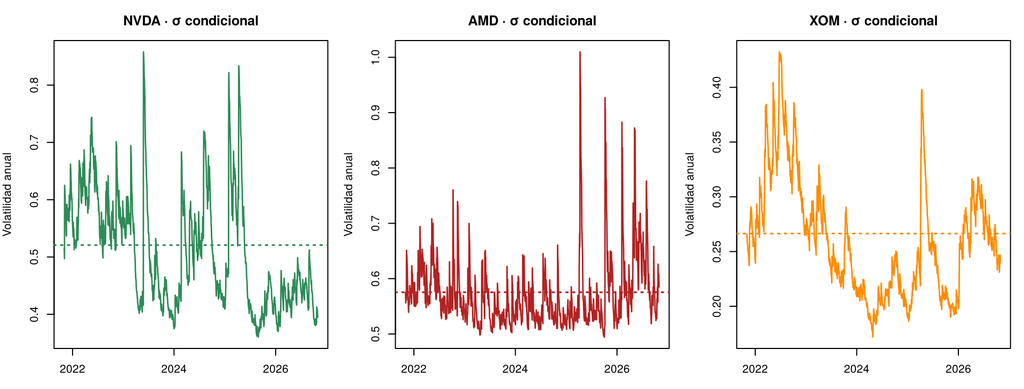

```r
op <- par(mfrow = c(1, 3), mar = c(3, 4, 3, 1))
for (t in tickers) {
  s <- vol_anual(M[[t]]$v)
  plot(tail(zoo::index(px), length(s)), s, type = "l", col = colores[t], lwd = 1.4, xlab = "", ylab = "Volatilidad anual", main = paste(t, "· σ condicional"))
  abline(h = vol_anual(M[[t]]$VL), lty = 3, col = colores[t], lwd = 1.6)
}
```

```r
par(op)
```

# 6 Pronóstico de volatilidad hasta el vencimiento (Hull 23.6)

$$E[\sigma^2_{n+k}] = V_L +
(\alpha+\beta)^k(\sigma^2_n - V_L)$$

Una opción que vence en $H$ días se valora con la **volatilidad promedio** de esos días (no la de hoy). **Esa es la σ que entra al árbol.**

```r
pron_var <- function(m, Hd) { k <- 0:(Hd - 1); m$VL + (m$p[2] + m$p[3])^k * (m$v_next - m$VL) }
vol_prom <- function(m, Hd) sqrt(252 * mean(pron_var(m, Hd))) / 100

vol_garch <- sapply(M, vol_prom, Hd = H)
iv        <- sapply(mercado, `[[`, "iv")
razon     <- vol_garch / iv

plazos <- c(10, 30, H, 126, 252)
est <- data.frame(Plazo = paste(plazos, "días"), sapply(M, function(m) sapply(plazos, function(d) vol_prom(m, d))))
knitr::kable(est, digits = 3, caption = "Volatilidad promedio esperada según el plazo")
```

Volatilidad promedio esperada según el plazo

| Plazo | NVDA | AMD | XOM |
| --- | --- | --- | --- |
| 10 días | 0.429 | 0.654 | 0.247 |
| 30 días | 0.451 | 0.611 | 0.248 |
| 34 días | 0.454 | 0.607 | 0.249 |
| 126 días | 0.493 | 0.584 | 0.254 |
| 252 días | 0.506 | 0.580 | 0.258 |

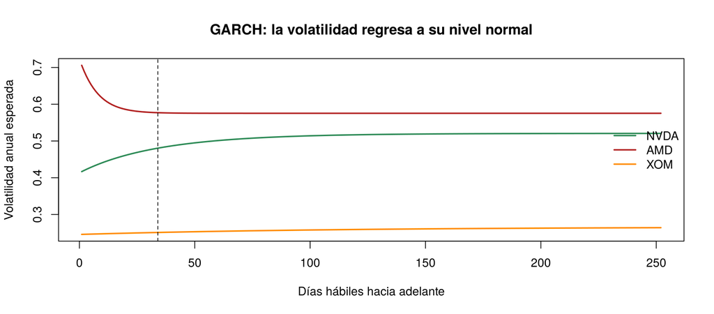

```r
matplot(1:252, sapply(M, function(m) vol_anual(pron_var(m, 252))), type = "l", lty = 1, lwd = 2, col = colores[tickers],
        xlab = "Días hábiles hacia adelante", ylab = "Volatilidad anual esperada", main = "GARCH: la volatilidad regresa a su nivel normal")
abline(v = H, lty = 2); legend("right", tickers, col = colores[tickers], lty = 1, lwd = 2, bty = "n")
```

```r
leer(sprintf("**%s**: hasta el 18-dic GARCH espera una volatilidad promedio de **%s**; el mercado cobra **%s** (razón %.2f).", tickers, pc(vol_garch), pc(iv), razon),
     "Razón mayor a 1: GARCH ve **más** movimiento que el mercado (opción barata). Menor a 1: ve **menos** (opción cara).",
     "GARCH no conoce las fechas de reporte de resultados (AMD ≈ 3-nov y NVDA ≈ 24-nov; XOM ya reportó el 30-oct y su precio ya lo refleja); es normal que quede algo por debajo de la implícita cuando hay un reporte dentro de la vida de la opción.")
```

> **En palabras simples**
> - **NVDA**: hasta el 18-dic GARCH espera una volatilidad promedio de **45.4 %**; el mercado cobra **41.4 %** (razón 1.10).
> - **AMD**: hasta el 18-dic GARCH espera una volatilidad promedio de **60.7 %**; el mercado cobra **58.6 %** (razón 1.04).
> - **XOM**: hasta el 18-dic GARCH espera una volatilidad promedio de **24.9 %**; el mercado cobra **29.9 %** (razón 0.83).
> - Razón mayor a 1: GARCH ve **más** movimiento que el mercado (opción barata). Menor a 1: ve **menos** (opción cara).
> - GARCH no conoce las fechas de reporte de resultados (AMD ≈ 3-nov y NVDA ≈ 24-nov; XOM ya reportó el 30-oct y su precio ya lo refleja); es normal que quede algo por debajo de la implícita cuando hay un reporte dentro de la vida de la opción.

# 7 Monte Carlo con GARCH

```r
simular <- function(m, S0, Hd, n, deriva) {
  v <- rep(m$p[1] + m$p[2] * tail(m$u, 1)^2 + m$p[3] * tail(m$v, 1), n)
  S <- matrix(S0, Hd + 1, n)
  for (k in 1:Hd) {
    sig <- sqrt(v); z <- rnorm(n)
    S[k + 1, ] <- S[k, ] * exp(deriva / 252 - 0.5 * (sig / 100)^2 + (sig / 100) * z)
    v <- m$p[1] + m$p[2] * (sig * z)^2 + m$p[3] * v
  }
  S
}
S0  <- sapply(mercado, `[[`, "S")
SIM <- lapply(tickers, function(t) simular(M[[t]], S0[t], H, N_SIM, mu)); names(SIM) <- tickers

mc_df <- do.call(rbind, lapply(tickers, function(t) {
  ST <- SIM[[t]][H + 1, ]; q <- quantile(ST, c(.05, .25, .5, .75, .95))
  data.frame(Accion = t, `Precio hoy` = S0[t], P5 = q[1], P25 = q[2], Mediana = q[3], P75 = q[4], P95 = q[5],
             `Prob. de subir` = mean(ST > S0[t]), `VaR 99% a 10 días` = -quantile(SIM[[t]][11, ] / S0[t] - 1, 0.01), check.names = FALSE)
}))
rownames(mc_df) <- NULL
knitr::kable(mc_df, digits = c(0, 2, 1, 1, 1, 1, 1, 3, 3), caption = "Precio simulado al vencimiento (mundo real)")
```

Precio simulado al vencimiento (mundo real)

| Accion | Precio hoy | P5 | P25 | Mediana | P75 | P95 | Prob. de subir | VaR 99% a 10 días |
| --- | --- | --- | --- | --- | --- | --- | --- | --- |
| NVDA | 204.64 | 154.8 | 182.8 | 204.2 | 227.7 | 268.3 | 0.494 | 0.185 |
| AMD | 504.80 | 344.9 | 428.6 | 497.4 | 577.2 | 717.1 | 0.474 | 0.271 |
| XOM | 187.25 | 162.3 | 177.6 | 188.7 | 200.3 | 219.2 | 0.535 | 0.108 |

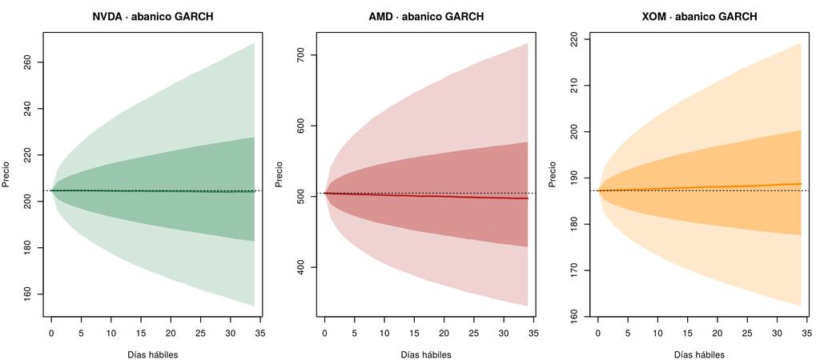

```r
op <- par(mfrow = c(1, 3), mar = c(4, 4, 3, 1))
for (t in tickers) {
  q <- apply(SIM[[t]], 1, quantile, c(.05, .25, .5, .75, .95))
  plot(0:H, q[3, ], type = "n", ylim = range(q), xlab = "Días hábiles", ylab = "Precio", main = paste(t, "· abanico GARCH"))
  polygon(c(0:H, H:0), c(q[1, ], rev(q[5, ])), col = adjustcolor(colores[t], .2), border = NA)
  polygon(c(0:H, H:0), c(q[2, ], rev(q[4, ])), col = adjustcolor(colores[t], .35), border = NA)
  lines(0:H, q[3, ], col = colores[t], lwd = 2); abline(h = S0[t], lty = 3)
}
```

```r
par(op)
```

```r
leer(sprintf("**%s**: con 90 %% de probabilidad el precio al 18-dic queda entre **%.0f y %.0f** (hoy %.2f); mediana %.0f.", tickers, mc_df$P5, mc_df$P95, mc_df$`Precio hoy`, mc_df$Mediana),
     "El abanico se ensancha con el tiempo: entre más lejos, más incertidumbre. Es la forma de **ver** la volatilidad pronosticada.",
     "El VaR de 99 % a 10 días es la pérdida que se superaría solo 1 vez de cada 100 en 2 semanas.")
```

> **En palabras simples**
> - **NVDA**: con 90 % de probabilidad el precio al 18-dic queda entre **155 y 268** (hoy 204.64); mediana 204.
> - **AMD**: con 90 % de probabilidad el precio al 18-dic queda entre **345 y 717** (hoy 504.80); mediana 497.
> - **XOM**: con 90 % de probabilidad el precio al 18-dic queda entre **162 y 219** (hoy 187.25); mediana 189.
> - El abanico se ensancha con el tiempo: entre más lejos, más incertidumbre. Es la forma de **ver** la volatilidad pronosticada.
> - El VaR de 99 % a 10 días es la pérdida que se superaría solo 1 vez de cada 100 en 2 semanas.

# 8 Árbol binomial americano (CRR) con la σ de GARCH

El árbol valora la opción; **GARCH le dice qué volatilidad usar**. Se usan 500 pasos, dividendo continuo $q$ y ejercicio anticipado.

```r
crr <- function(S0, K, r, sig, T, N = 500, tipo = "put", amer = TRUE, q = 0) {
  dt <- T / N; u <- exp(sig * sqrt(dt)); d <- 1 / u
  p <- (exp((r - q) * dt) - d) / (u - d); disc <- exp(-r * dt); sg <- if (tipo == "call") 1 else -1
  j <- 0:N; V <- pmax(sg * (S0 * u^(N - j) * d^j - K), 0); niv <- list()
  for (i in (N - 1):0) {
    k <- 0:i; cont <- disc * (p * V[1:(i + 1)] + (1 - p) * V[2:(i + 2)])
    V <- if (amer) pmax(cont, pmax(sg * (S0 * u^(i - k) * d^k - K), 0)) else cont
    if (i <= 2) niv[[i + 1]] <- V
  }
  list(precio = V[1], niv = niv, u = u, d = d, dt = dt)
}
precio <- function(S0, K, sig, T, tipo, amer = TRUE, q = 0, N = 500, rr = r) crr(S0, K, rr, sig, T, N, tipo, amer, q)$precio
griegas <- function(S0, K, sig, T, tipo, q = 0, N = 500) {
  a <- crr(S0, K, r, sig, T, N, tipo, TRUE, q); f0 <- a$niv[[1]][1]; f1 <- a$niv[[2]]; f2 <- a$niv[[3]]; u <- a$u; d <- a$d
  c(precio = a$precio,
    delta = (f1[1] - f1[2]) / (S0 * u - S0 * d),
    gamma = ((f2[1] - f2[2]) / (S0 * u^2 - S0) - (f2[2] - f2[3]) / (S0 - S0 * d^2)) / (0.5 * (S0 * u^2 - S0 * d^2)),
    theta = (f2[2] - f0) / (2 * a$dt) / 365,
    vega  = crr(S0, K, r, sig + 0.01, T, N, tipo, TRUE, q)$precio - a$precio,
    rho   = crr(S0, K, r + 0.01, sig, T, N, tipo, TRUE, q)$precio - a$precio)
}

# Valor de la opción con tres volatilidades distintas
val <- do.call(rbind, lapply(tickers, function(t) { m <- mercado[[t]]
  do.call(rbind, lapply(c("call", "put"), function(tp) {
    data.frame(Accion = t, Opcion = paste(tp, m$K),
               `σ histórica 1a` = precio(m$S, m$K, vol_1a[t], T_anios, tp, TRUE, m$q),
               `σ GARCH` = precio(m$S, m$K, vol_garch[t], T_anios, tp, TRUE, m$q),
               `σ implícita` = precio(m$S, m$K, m$iv, T_anios, tp, TRUE, m$q),
               Bid = m[[tp]][1], Ask = m[[tp]][2], check.names = FALSE) })) }))
knitr::kable(val, digits = 2, row.names = FALSE, caption = "Valor del árbol (USD por acción) según la volatilidad usada, frente al mercado")
```

Valor del árbol (USD por acción) según la volatilidad usada, frente al mercado

| Accion | Opcion | σ histórica 1a | σ GARCH | σ implícita | Bid | Ask |
| --- | --- | --- | --- | --- | --- | --- |
| NVDA | call 200 | 13.98 | 16.35 | 15.20 | 15.55 | 15.75 |
| NVDA | put 200 | 8.47 | 10.83 | 9.68 | 9.85 | 10.00 |
| AMD | call 500 | 54.00 | 48.24 | 46.71 | 46.85 | 48.50 |
| AMD | put 500 | 46.73 | 40.96 | 39.43 | 39.70 | 40.75 |
| XOM | call 185 | 8.54 | 8.15 | 9.50 | 8.75 | 9.20 |
| XOM | put 185 | 5.90 | 5.51 | 6.86 | 6.80 | 7.30 |

```r
mid_mkt <- (val$Bid + val$Ask) / 2; dif_iv <- abs(val$`σ implícita` - mid_mkt); pdif_iv <- max(dif_iv / mid_mkt)
leer("Si el valor con **σ GARCH** es mayor que el **ask**, el modelo dice que la opción está barata; si es menor, cara.",
     sprintf("Con la σ implícita el árbol reproduce el precio medio de mercado con una diferencia máxima de %.2f USD por acción (%s). No es exacta porque la volatilidad implícita que muestra TradingView sale de su propio modelo y las cotizaciones son las del último cierre; aun así sirve de comprobación de que el árbol está bien armado.", max(dif_iv), pc(pdif_iv)))
```

> **En palabras simples**
> - Si el valor con **σ GARCH** es mayor que el **ask**, el modelo dice que la opción está barata; si es menor, cara.
> - Con la σ implícita el árbol reproduce el precio medio de mercado con una diferencia máxima de 0.97 USD por acción (5.9 %). No es exacta porque la volatilidad implícita que muestra TradingView sale de su propio modelo y las cotizaciones son las del último cierre; aun así sirve de comprobación de que el árbol está bien armado.

## 8.1 Griegas de la opción comprada (por contrato, con σ GARCH)

```r
gr <- do.call(rbind, lapply(tickers, function(t) { m <- mercado[[t]]; g <- griegas(m$S, m$K, vol_garch[t], T_anios, m$compra, m$q)
  g <- unname(g); data.frame(Accion = t, Opcion = paste(m$compra, m$K), `Delta (acciones)` = g[2] * mult, Gamma = g[3] * mult,
             `Theta (USD/día)` = g[4] * mult, `Vega (USD por +1 pto)` = g[5] * mult, `Rho (USD por +1 pto)` = g[6] * mult, check.names = FALSE) }))
rownames(gr) <- NULL
knitr::kable(gr, digits = 2, caption = "Griegas por contrato (100 acciones)")
```

Griegas por contrato (100 acciones)

| Accion | Opcion | Delta (acciones) | Gamma | Theta (USD/día) | Vega (USD por +1 pto) | Rho (USD por +1 pto) |
| --- | --- | --- | --- | --- | --- | --- |
| NVDA | call 200 | 59.79 | 1.14 | -14.42 | 29.01 | 14.27 |
| AMD | put 500 | -43.17 | 0.35 | -42.66 | 72.66 | -29.41 |
| XOM | call 185 | 57.87 | 2.29 | -7.20 | 26.74 | 13.52 |

```r
leer(sprintf("**%s %s %s**: se comporta como %.0f acciones; pierde **%.2f USD por día** por el paso del tiempo; si la volatilidad sube 1 punto gana %.2f USD.",
             gr$Accion, toupper(sub(" .*", "", gr$Opcion)), sub(".* ", "", gr$Opcion), abs(gr$`Delta (acciones)`), abs(gr$`Theta (USD/día)`), gr$`Vega (USD por +1 pto)`))
```

> **En palabras simples**
> - **NVDA CALL 200**: se comporta como 60 acciones; pierde **14.42 USD por día** por el paso del tiempo; si la volatilidad sube 1 punto gana 29.01 USD.
> - **AMD PUT 500**: se comporta como 43 acciones; pierde **42.66 USD por día** por el paso del tiempo; si la volatilidad sube 1 punto gana 72.66 USD.
> - **XOM CALL 185**: se comporta como 58 acciones; pierde **7.20 USD por día** por el paso del tiempo; si la volatilidad sube 1 punto gana 26.74 USD.

## 8.2 ¿Vale la pena el ejercicio anticipado?

```r
am <- do.call(rbind, lapply(tickers, function(t) { m <- mercado[[t]]
  do.call(rbind, lapply(c("call", "put"), function(tp) {
    a <- precio(m$S, m$K, vol_garch[t], T_anios, tp, TRUE, m$q); e <- precio(m$S, m$K, vol_garch[t], T_anios, tp, FALSE, m$q)
    data.frame(Accion = t, Opcion = tp, Americana = a, Europea = e, `Prima de ejercicio anticipado` = a - e, check.names = FALSE) })) }))
knitr::kable(am, digits = 3, row.names = FALSE)
```

| Accion | Opcion | Americana | Europea | Prima de ejercicio anticipado |
| --- | --- | --- | --- | --- |
| NVDA | call | 16.349 | 16.349 | 0.000 |
| NVDA | put | 10.832 | 10.783 | 0.050 |
| AMD | call | 48.237 | 48.237 | 0.000 |
| AMD | put | 40.962 | 40.800 | 0.162 |
| XOM | call | 8.151 | 8.151 | 0.000 |
| XOM | put | 5.514 | 5.490 | 0.024 |

```r
leer("La **put** americana siempre vale algo más que la europea: puede convenir ejercer antes para cobrar el strike y ganar intereses.",
     "La **call** solo conviene ejercerla antes si la acción paga dividendos mayores a lo que se ganaría esperando (XOM, y muy poco NVDA). Sin dividendos, call americana = call europea.")
```

[output not shown]

## 8.3 Niveles de nodos del árbol (4 pasos, con la σ de GARCH)

Para ver el árbol «a mano» se dibujan solo 4 pasos (el cálculo real usa 500). En cada nodo se compara **ejercer ya** con **esperar**.

```r
arbol_niveles <- function(S0, K, r, sig, T, N = 4, tipo = "call", q = 0) {
  dt <- T / N; u <- exp(sig * sqrt(dt)); d <- 1 / u
  p <- (exp((r - q) * dt) - d) / (u - d); disc <- exp(-r * dt); sg <- if (tipo == "call") 1 else -1
  S <- lapply(0:N, function(i) S0 * u^(i - 0:i) * d^(0:i))
  V <- vector("list", N + 1); EX <- vector("list", N + 1)
  V[[N + 1]] <- pmax(sg * (S[[N + 1]] - K), 0); EX[[N + 1]] <- rep(FALSE, N + 1)
  for (i in (N - 1):0) {
    cont <- disc * (p * V[[i + 2]][1:(i + 1)] + (1 - p) * V[[i + 2]][2:(i + 2)])
    ex <- pmax(sg * (S[[i + 1]] - K), 0)
    V[[i + 1]] <- pmax(cont, ex); EX[[i + 1]] <- ex > cont + 1e-12 & ex > 0
  }
  list(S = S, V = V, EX = EX, u = u, d = d, p = p)
}
n_ex <- c()
for (t in tickers) {
  m <- mercado[[t]]; a <- arbol_niveles(m$S, m$K, r, vol_garch[t], T_anios, 4, m$compra, m$q)
  filas <- do.call(rbind, lapply(c(0, 1, 2, 4), function(i) data.frame(
    Paso = i, `Nodo (bajas)` = 0:i, `Precio de la acción` = a$S[[i + 1]], `Valor de la opción` = a$V[[i + 1]],
    `Mejor acción` = ifelse(a$EX[[i + 1]], "Ejercer", ifelse(i == 4, "Vence", "Esperar")), check.names = FALSE)))
  n_ex[t] <- sum(unlist(a$EX))
  cat(sprintf("\n\n**%s · %s %g · σ GARCH %s · u = %.4f, d = %.4f, p = %.4f** (pasos 0, 1, 2 y 4)\n\n", t, m$compra, m$K, pc(vol_garch[t]), a$u, a$d, a$p))
  print(knitr::kable(filas, digits = 2, row.names = FALSE))
}
```

**NVDA · call 200 · σ GARCH 45.4 % · u = 1.0868, d = 0.9202, p = 0.4862** (pasos 0, 1, 2 y 4)

| Paso | Nodo (bajas) | Precio de la acción | Valor de la opción | Mejor acción |
| --- | --- | --- | --- | --- |
| 0 | 0 | 204.64 | 16.27 | Esperar |
| 1 | 0 | 222.39 | 26.69 | Esperar |
| 1 | 1 | 188.30 | 6.46 | Esperar |
| 2 | 0 | 241.69 | 42.14 | Esperar |
| 2 | 1 | 204.64 | 12.14 | Esperar |
| 2 | 2 | 173.27 | 1.09 | Esperar |
| 4 | 0 | 285.45 | 85.45 | Vence |
| 4 | 1 | 241.69 | 41.69 | Vence |
| 4 | 2 | 204.64 | 4.64 | Vence |
| 4 | 3 | 173.27 | 0.00 | Vence |
| 4 | 4 | 146.71 | 0.00 | Vence |

**AMD · put 500 · σ GARCH 60.7 % · u = 1.1177, d = 0.8947, p = 0.4781** (pasos 0, 1, 2 y 4)

| Paso | Nodo (bajas) | Precio de la acción | Valor de la opción | Mejor acción |
| --- | --- | --- | --- | --- |
| 0 | 0 | 504.80 | 39.05 | Esperar |
| 1 | 0 | 564.22 | 13.58 | Esperar |
| 1 | 1 | 451.64 | 62.50 | Esperar |
| 2 | 0 | 630.63 | 0.00 | Esperar |
| 2 | 1 | 504.80 | 26.05 | Esperar |
| 2 | 2 | 404.08 | 96.04 | Esperar |
| 4 | 0 | 787.83 | 0.00 | Vence |
| 4 | 1 | 630.63 | 0.00 | Vence |
| 4 | 2 | 504.80 | 0.00 | Vence |
| 4 | 3 | 404.08 | 95.92 | Vence |
| 4 | 4 | 323.45 | 176.55 | Vence |

**XOM · call 185 · σ GARCH 24.9 % · u = 1.0466, d = 0.9555, p = 0.4948** (pasos 0, 1, 2 y 4)

| Paso | Nodo (bajas) | Precio de la acción | Valor de la opción | Mejor acción |
| --- | --- | --- | --- | --- |
| 0 | 0 | 187.25 | 8.10 | Esperar |
| 1 | 0 | 195.98 | 13.07 | Esperar |
| 1 | 1 | 178.91 | 3.26 | Esperar |
| 2 | 0 | 205.11 | 20.29 | Esperar |
| 2 | 1 | 187.25 | 6.03 | Esperar |
| 2 | 2 | 170.95 | 0.55 | Esperar |
| 4 | 0 | 224.67 | 39.67 | Vence |
| 4 | 1 | 205.11 | 20.11 | Vence |
| 4 | 2 | 187.25 | 2.25 | Vence |
| 4 | 3 | 170.95 | 0.00 | Vence |
| 4 | 4 | 156.06 | 0.00 | Vence |

```r
leer(sprintf("Cada paso son ~%.0f días. En cada nodo la acción sube (×u) o baja (×d); el valor de la opción se calcula de atrás hacia adelante, igual que en el trabajo de árboles.", dias_cal / 4),
     "«Ejercer» aparece cuando cobrar el valor intrínseco ya vale más que esperar; en una call sin dividendos casi nunca ocurre, y en una put sí puede ocurrir en los nodos donde la acción cayó mucho.",
     sprintf("**%s**: nodos de ejercicio anticipado en el árbol de 4 pasos: %d.", tickers, n_ex[tickers]))
```

> **En palabras simples**
> - Cada paso son ~12 días. En cada nodo la acción sube (×u) o baja (×d); el valor de la opción se calcula de atrás hacia adelante, igual que en el trabajo de árboles.
> - «Ejercer» aparece cuando cobrar el valor intrínseco ya vale más que esperar; en una call sin dividendos casi nunca ocurre, y en una put sí puede ocurrir en los nodos donde la acción cayó mucho.
> - **NVDA**: nodos de ejercicio anticipado en el árbol de 4 pasos: 0.
> - **AMD**: nodos de ejercicio anticipado en el árbol de 4 pasos: 1.
> - **XOM**: nodos de ejercicio anticipado en el árbol de 4 pasos: 0.

## 8.4 Comprobación: Monte Carlo (σ GARCH) vs. árbol europeo

```r
chk <- do.call(rbind, lapply(tickers, function(t) { m <- mercado[[t]]
  ST <- simular(M[[t]], m$S, H, N_SIM * 2, r - m$q)[H + 1, ]; dsc <- exp(-r * T_anios)
  data.frame(Accion = t, `Call MC` = dsc * mean(pmax(ST - m$K, 0)), `Call árbol` = precio(m$S, m$K, vol_garch[t], T_anios, "call", FALSE, m$q),
             `Put MC` = dsc * mean(pmax(m$K - ST, 0)), `Put árbol` = precio(m$S, m$K, vol_garch[t], T_anios, "put", FALSE, m$q), check.names = FALSE) }))
knitr::kable(chk, digits = 3, row.names = FALSE, caption = "Opciones europeas: simulación completa vs. árbol con σ promedio")
```

Opciones europeas: simulación completa vs. árbol con σ promedio

| Accion | Call MC | Call árbol | Put MC | Put árbol |
| --- | --- | --- | --- | --- |
| NVDA | 16.233 | 16.349 | 10.678 | 10.783 |
| AMD | 48.031 | 48.237 | 40.488 | 40.800 |
| XOM | 8.114 | 8.151 | 5.423 | 5.490 |

```r
leer("Si los dos métodos coinciden, usar la **volatilidad promedio de GARCH** dentro del árbol es una buena aproximación para un plazo de 2 meses.")
```

> **En palabras simples**
> - Si los dos métodos coinciden, usar la **volatilidad promedio de GARCH** dentro del árbol es una buena aproximación para un plazo de 2 meses.

# 9 Estrategia: señal de volatilidad y resultado esperado

**Señal** (presentación, diap. 15): razón = σ GARCH promedio ÷ σ implícita.

- **> 1.10**: GARCH ve más volatilidad que el mercado → opción barata → **comprar volatilidad** (straddle largo: call + put).
- **0.90 – 1.10**: **sin ventaja** en volatilidad.
- **< 0.90**: opción cara → **no comprar** por volatilidad.

El resultado esperado se estima con trayectorias GARCH «del mundo real» y se compra al **ask**.

```r
senal <- function(x) if (x > 1 + umbral) "COMPRAR volatilidad" else if (x < 1 - umbral) "NO COMPRAR (opción cara)" else "SIN VENTAJA en volatilidad"

ST_real <- lapply(tickers, function(t) simular(M[[t]], S0[t], H, N_SIM * 2, mu)[H + 1, ]); names(ST_real) <- tickers
SEN <- do.call(rbind, lapply(tickers, function(t) { m <- mercado[[t]]; ST <- ST_real[[t]]
  costo <- m$call[2] + m$put[2]; pnl <- pmax(ST - m$K, 0) + pmax(m$K - ST, 0) - costo
  data.frame(Accion = t, Razon = razon[t], `Señal` = senal(razon[t]), `Costo straddle (USD/acción)` = costo,
             `Equilibrio inferior` = m$K - costo, `Equilibrio superior` = m$K + costo, `P&L esperado (USD/acción)` = mean(pnl), `Prob. de ganar` = mean(pnl > 0), check.names = FALSE) }))
knitr::kable(SEN, digits = 2, row.names = FALSE, caption = "Straddle largo (call + put al mismo strike)")
```

Straddle largo (call + put al mismo strike)

| Accion | Razon | Señal | Costo straddle (USD/acción) | Equilibrio inferior | Equilibrio superior | P&L esperado (USD/acción) | Prob. de ganar |
| --- | --- | --- | --- | --- | --- | --- | --- |
| NVDA | 1.10 | SIN VENTAJA en volatilidad | 25.75 | 174.25 | 225.75 | 1.55 | 0.43 |
| AMD | 1.04 | SIN VENTAJA en volatilidad | 89.25 | 410.75 | 589.25 | 0.28 | 0.41 |
| XOM | 0.83 | NO COMPRAR (opción cara) | 16.50 | 168.50 | 201.50 | -2.56 | 0.33 |

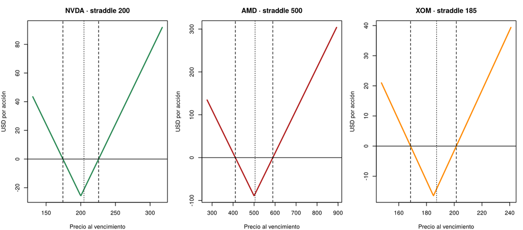

```r
op <- par(mfrow = c(1, 3), mar = c(4, 4, 3, 1))
for (t in tickers) { m <- mercado[[t]]; s <- SEN[SEN$Accion == t, ]
  g <- seq(quantile(ST_real[[t]], .005), quantile(ST_real[[t]], .995), length.out = 200)
  plot(g, pmax(g - m$K, 0) + pmax(m$K - g, 0) - s$`Costo straddle (USD/acción)`, type = "l", lwd = 2.2, col = colores[t],
       xlab = "Precio al vencimiento", ylab = "USD por acción", main = paste(t, "· straddle", m$K))
  abline(h = 0); abline(v = c(s$`Equilibrio inferior`, s$`Equilibrio superior`), lty = 2); abline(v = m$S, lty = 3) }
```

```r
par(op)
```

```r
leer(sprintf("**%s** · razón %.2f → **%s**. Un straddle cuesta %.2f por acción: gana solo si al vencimiento la acción queda debajo de %.0f o arriba de %.0f. Probabilidad de ganar según GARCH: %s.",
             SEN$Accion, SEN$Razon, SEN$`Señal`, SEN$`Costo straddle (USD/acción)`, SEN$`Equilibrio inferior`, SEN$`Equilibrio superior`, pc(SEN$`Prob. de ganar`, 0)),
     "El straddle gana con movimientos grandes en cualquier dirección y pierde si la acción casi no se mueve. Solo conviene cuando GARCH espera más volatilidad de la que cobra el mercado.")
```

> **En palabras simples**
> - **NVDA** · razón 1.10 → **SIN VENTAJA en volatilidad**. Un straddle cuesta 25.75 por acción: gana solo si al vencimiento la acción queda debajo de 174 o arriba de 226. Probabilidad de ganar según GARCH: 43 %.
> - **AMD** · razón 1.04 → **SIN VENTAJA en volatilidad**. Un straddle cuesta 89.25 por acción: gana solo si al vencimiento la acción queda debajo de 411 o arriba de 589. Probabilidad de ganar según GARCH: 41 %.
> - **XOM** · razón 0.83 → **NO COMPRAR (opción cara)**. Un straddle cuesta 16.50 por acción: gana solo si al vencimiento la acción queda debajo de 168 o arriba de 202. Probabilidad de ganar según GARCH: 33 %.
> - El straddle gana con movimientos grandes en cualquier dirección y pierde si la acción casi no se mueve. Solo conviene cuando GARCH espera más volatilidad de la que cobra el mercado.

## 9.1 La posición direccional de la tarea de árboles

```r
POS <- lapply(tickers, function(t) { m <- mercado[[t]]; ST <- ST_real[[t]]; tp <- m$compra; ask <- m[[tp]][2]
  pay <- if (tp == "call") pmax(ST - m$K, 0) else pmax(m$K - ST, 0); pnl <- (pay - ask) * mult * m$n
  list(tipo = tp, ask = ask, n = m$n, costo = ask * mult * m$n, prob_itm = mean(pay > 0), prob_gan = mean(pnl > 0), pnl_esp = mean(pnl), p5 = quantile(pnl, .05), p95 = quantile(pnl, .95), pnl = pnl) })
names(POS) <- tickers
pos_df <- do.call(rbind, lapply(tickers, function(t) with(POS[[t]], data.frame(Accion = t, Opcion = paste(tipo, mercado[[t]]$K), Contratos = n, Ask = ask,
  `Costo total (USD)` = costo, `Prob. en el dinero` = prob_itm, `Prob. de ganar` = prob_gan, `P&L esperado (USD)` = pnl_esp, `P5 (USD)` = p5, `P95 (USD)` = p95, check.names = FALSE))))
rownames(pos_df) <- NULL
knitr::kable(pos_df, digits = c(0, 0, 0, 2, 0, 3, 3, 0, 0, 0), caption = "Resultado al 18-dic según GARCH")
```

Resultado al 18-dic según GARCH

| Accion | Opcion | Contratos | Ask | Costo total (USD) | Prob. en el dinero | Prob. de ganar | P&L esperado (USD) | P5 (USD) | P95 (USD) |
| --- | --- | --- | --- | --- | --- | --- | --- | --- | --- |
| NVDA | call 200 | 2 | 15.75 | 3150 | 0.548 | 0.365 | 262 | -3150 | 10477 |
| AMD | put 500 | 1 | 40.75 | 4075 | 0.507 | 0.355 | -121 | -4075 | 11440 |
| XOM | call 185 | 3 | 9.20 | 2760 | 0.585 | 0.370 | -19 | -2760 | 7407 |

```r
leer(sprintf("**%s** (%s × %d): costo %.0f USD, que es lo máximo que se puede perder. Probabilidad de ganar %s; resultado esperado %+.0f USD.",
             pos_df$Accion, pos_df$Opcion, pos_df$Contratos, pos_df$`Costo total (USD)`, pc(pos_df$`Prob. de ganar`, 0), pos_df$`P&L esperado (USD)`),
     sprintf("Los resultados dependen del rendimiento supuesto (%s anual): son una guía, no una promesa.", pc(mu, 0)))
```

> **En palabras simples**
> - **NVDA** (call 200 × 2): costo 3150 USD, que es lo máximo que se puede perder. Probabilidad de ganar 36 %; resultado esperado +262 USD.
> - **AMD** (put 500 × 1): costo 4075 USD, que es lo máximo que se puede perder. Probabilidad de ganar 36 %; resultado esperado -121 USD.
> - **XOM** (call 185 × 3): costo 2760 USD, que es lo máximo que se puede perder. Probabilidad de ganar 37 %; resultado esperado -19 USD.
> - Los resultados dependen del rendimiento supuesto (8 % anual): son una guía, no una promesa.

# 10 ¿Qué tan sólida es la señal?

La señal depende de **un** pronóstico. Se repite la razón con otras formas de medir la volatilidad: GARCH con 5, 3 y 2 años, la histórica de 1 año y EWMA. Si al menos 3 de las 4 alternativas coinciden con la señal base (GARCH de 5 años), la señal es **sólida**; si no, es **frágil**.

```r
vol_ventana <- function(t, n) {
  x <- tail(u[[t]], n); p <- ajustar_garch(x)$par; v <- var_garch(p, x); VL <- p[1] / (1 - p[2] - p[3])
  vn <- p[1] + p[2] * tail(x, 1)^2 + p[3] * tail(v, 1); sqrt(252 * mean(VL + (p[2] + p[3])^(0:(H - 1)) * (vn - VL))) / 100
}
ROB <- do.call(rbind, lapply(tickers, function(t) {
  med <- c(`GARCH 5 años` = unname(vol_garch[t]), `GARCH 3 años` = vol_ventana(t, 756), `GARCH 2 años` = vol_ventana(t, 504),
           `Histórica 1 año` = unname(vol_1a[t]), `EWMA hoy` = unname(ewma_hoy[t]))
  rz <- med / iv[t]; base <- senal(rz[1]); coinc <- sum(sapply(rz[-1], senal) == base)
  data.frame(Accion = t, t(round(rz, 2)), `Coinciden (de 4)` = coinc, Solidez = if (coinc >= 3) "Sólida" else "Frágil", check.names = FALSE) }))
knitr::kable(ROB, row.names = FALSE, caption = "Razón σ / σ implícita según cómo se mida la volatilidad")
```

Razón σ / σ implícita según cómo se mida la volatilidad

| Accion | GARCH 5 años | GARCH 3 años | GARCH 2 años | Histórica 1 año | EWMA hoy | Coinciden (de 4) | Solidez |
| --- | --- | --- | --- | --- | --- | --- | --- |
| NVDA | 1.10 | 1.07 | 1.02 | 0.90 | 0.83 | 2 | Frágil |
| AMD | 1.04 | 1.06 | 1.18 | 1.17 | 1.23 | 1 | Frágil |
| XOM | 0.83 | 0.79 | 0.84 | 0.88 | 0.80 | 4 | Sólida |

```r
leer(sprintf("**%s**: coinciden %d de 4 → señal **%s**.", ROB$Accion, ROB$`Coinciden (de 4)`, tolower(ROB$Solidez)),
     "Una señal frágil depende de cómo se estime la volatilidad (por ejemplo, de que GARCH regrese a un nivel «normal» calculado con años en que la acción se comportó distinto).",
     "Una razón apenas arriba de 1.10 o abajo de 0.90 también es débil: un cambio pequeño en los datos la mueve de categoría.")
```

> **En palabras simples**
> - **NVDA**: coinciden 2 de 4 → señal **frágil**.
> - **AMD**: coinciden 1 de 4 → señal **frágil**.
> - **XOM**: coinciden 4 de 4 → señal **sólida**.
> - Una señal frágil depende de cómo se estime la volatilidad (por ejemplo, de que GARCH regrese a un nivel «normal» calculado con años en que la acción se comportó distinto).
> - Una razón apenas arriba de 1.10 o abajo de 0.90 también es débil: un cambio pequeño en los datos la mueve de categoría.

# 11 Decisión para Investopedia

Tamaño por posición: mismo presupuesto de la tarea de árboles (**3,000 USD**). **Costo total = ask × 100 × contratos.** La pérdida máxima de una opción comprada es lo que se paga.

```r
contratos_para <- function(c_unit) max(1, round(presupuesto / (c_unit * mult)))
DEC <- lapply(tickers, function(t) { m <- mercado[[t]]; p <- POS[[t]]; rz <- razon[t]; solida <- ROB$Solidez[ROB$Accion == t] == "Sólida"; ST <- ST_real[[t]]
  if (rz > 1 + umbral) {
    cu <- m$call[2] + m$put[2]; n <- contratos_para(cu); pnl <- (pmax(ST - m$K, 0) + pmax(m$K - ST, 0) - cu)
    list(accion = paste0("COMPRAR straddle (call + put)", if (!solida) " (señal frágil)" else ""), n = n, contrato = sprintf("CALL %g @ %.2f + PUT %g @ %.2f", m$K, m$call[2], m$K, m$put[2]),
         costo = cu * mult * n, pg = mean(pnl > 0), pe = mean(pnl) * mult * n)
  } else if (rz < 1 - umbral) {
    list(accion = "NO COMPRAR por volatilidad (opción cara)", n = 0, contrato = sprintf("Si se compra por tesis direccional: %s %g @ %.2f", toupper(p$tipo), m$K, p$ask),
         costo = 0, pg = p$prob_gan, pe = p$pnl_esp)
  } else {
    n <- contratos_para(p$ask); pay <- if (p$tipo == "call") pmax(ST - m$K, 0) else pmax(m$K - ST, 0); pnl <- pay - p$ask
    list(accion = sprintf("MANTENER solo la %s direccional (sin ventaja de volatilidad)", toupper(p$tipo)), n = n, contrato = sprintf("%s %g @ %.2f", toupper(p$tipo), m$K, p$ask),
         costo = p$ask * mult * n, pg = mean(pnl > 0), pe = mean(pnl) * mult * n)
  } }); names(DEC) <- tickers
dec_df <- do.call(rbind, lapply(tickers, function(t) with(DEC[[t]], data.frame(Accion = t, Razon = razon[t], Decision = accion, Contrato = contrato, Contratos = n,
  `Costo total (USD)` = costo, `Prob. de ganar` = pg, `P&L esperado (USD)` = pe, check.names = FALSE))))
rownames(dec_df) <- NULL
knitr::kable(dec_df, digits = c(0, 2, 0, 0, 0, 0, 2, 0))
```

| Accion | Razon | Decision | Contrato | Contratos | Costo total (USD) | Prob. de ganar | P&L esperado (USD) |
| --- | --- | --- | --- | --- | --- | --- | --- |
| NVDA | 1.10 | MANTENER solo la CALL direccional (sin ventaja de volatilidad) | CALL 200 @ 15.75 | 2 | 3150 | 0.36 | 262 |
| AMD | 1.04 | MANTENER solo la PUT direccional (sin ventaja de volatilidad) | PUT 500 @ 40.75 | 1 | 4075 | 0.36 | -121 |
| XOM | 0.83 | NO COMPRAR por volatilidad (opción cara) | Si se compra por tesis direccional: CALL 185 @ 9.20 | 0 | 0 | 0.37 | -19 |

```r
total_dec <- sum(sapply(DEC, `[[`, "costo"))
```

```r
leer(sprintf("**%s**: %s. %s", tickers, dec_df$Decision,
             ifelse(dec_df$`P&L esperado (USD)` < 0 & dec_df$Contratos > 0, "Ojo: con el rendimiento supuesto el resultado esperado es negativo; es una apuesta direccional, no una ventaja de volatilidad.",
                    ifelse(dec_df$Contratos == 0, "GARCH no ve el reporte de resultados que sí está en la implícita; tomar con cautela.", ""))),
     sprintf("Costo total de las decisiones: **%s USD**, es decir %s del capital de %s USD (la pérdida máxima es ese monto).", format(round(total_dec), big.mark = ","), pc(total_dec / capital), format(capital, big.mark = ",", scientific = FALSE)),
     "Esta tabla es la que se lleva a Investopedia: contrato, cantidad y costo. Siempre hay riesgo: una opción comprada puede perder todo lo pagado. Ejercicio académico, no recomendación de inversión.")
```

> **En palabras simples**
> - **NVDA**: MANTENER solo la CALL direccional (sin ventaja de volatilidad).
> - **AMD**: MANTENER solo la PUT direccional (sin ventaja de volatilidad). Ojo: con el rendimiento supuesto el resultado esperado es negativo; es una apuesta direccional, no una ventaja de volatilidad.
> - **XOM**: NO COMPRAR por volatilidad (opción cara). GARCH no ve el reporte de resultados que sí está en la implícita; tomar con cautela.
> - Costo total de las decisiones: **7,225 USD**, es decir 7.2 % del capital de 100,000 USD (la pérdida máxima es ese monto).
> - Esta tabla es la que se lleva a Investopedia: contrato, cantidad y costo. Siempre hay riesgo: una opción comprada puede perder todo lo pagado. Ejercicio académico, no recomendación de inversión.